# Applying pySCA for any protein of interest part I

### Written by Thuy N. Nguyen, 191125

These are intended to supplement pySCA documentation here: https://ranganathanlab.gitlab.io/pySCA/install/

The goal of these general_pySCA usage notebooks is for users to be able to easily apply SCA to their protein of interest. In this first, the user will initialize path variables and then execute the first two steps of SCA: annotating and processing a multiple sequence alignment for their protein of interest. The user will then evaluate whether or not the multiple sequence alignment is appropriate for further analysis with SCA.

```python
##### User must Initailize path variables ############################################################

p = '/Users/thuynguyen/Documents' #path to pySCA directory

path2pfamseq = p+'/pfamseq.txt' #path to PFAM file

path2pfamseqdb = 'None' # To use PFAM as a SQLite3 database rather than a text file,
                        # exectue the shell script getPfamDB.sh.
                        # I haven't tried this yet but Ansel claims its a lot
                        # faster than iterating through the .txt file

path2structures = p+'/pySCA/data/' #PDB structure lives in this folder

path2output = p+'/pySCA/output/' #Expected outputs folder

# Used for pulling species, taxonomy annotations from ncbi database. PLEASE
entrezemail = "myemail[at]institution[dot]edu" # change to your own your email!!!
```

```python
#this defaults plots to matplotlib 1.0 formatting
import matplotlib.style
import matplotlib as mpl
#mpl.style.use('classic')
%matplotlib inline
mpl.rcParams['figure.dpi']= 150

# importing packages needed to run this script
from subprocess import call
import pickle as pickle
%matplotlib inline
import matplotlib.pyplot as plt
import numpy as np
import scipy.cluster.hierarchy as sch
```

## The annotateMSA script provides utilities to automatically annotate sequence headers (for a FASTA file) with taxonomic information. Currently this can be done in one of two ways:

```
1) For Pfam alignments, annotations can be extracted from the file
   pfamseq.txt (please download from:
   ftp://ftp.ebi.ac.uk/pub/databases/Pfam/current_release/database_files/pfamseq.txt.gz

2) For Blast alignments, annotations can be added using the NCBI Entrez
   utilities provided by BioPython. They can be based on GI or accession
   numbers that are used to query NCBI for taxonomy information (note that
   this approach requires a network connection).
```

To extract GI or accession numbers, use the scripts alnParseGI.py or alnParseAcc.py, respectively.

For both the Pfam and NCBI utilities, the process of sequence annotation *can be slow* (on the order of hours, particularly for NCBI entrez with larger alignments). However, the annotation process only needs to be run once per alignment.

**Let's apply annotateMSA to our example alignment**

```python
###### First, initialize with arguments for annotateMSA ##################################################################################
MSAname = 'PF00186_full.an' #name of multiple sequence alignment
MSAinput = p+'/pySCA/data/%s' % MSAname
annotateOutput = path2output+'%s' %MSAname
##########################################################################################################################################

#Run annotateMSA on your protein of interest
#command = str('annotateMSA -i %s -a %s -p %s -e %s -o %s' % (MSAinput,'pfam',path2pfamseq,entrezemail,annotateOutput))
#print(command)
#call(command,shell = 'True')
```

## The scaProcessMSA script conducts the basic steps in multiple sequence alignment (MSA) pre-processing for SCA, and stores the results using the python tool pickle:

1) Trim the alignment, either by truncating to a reference sequence (specified with the -t flag) or by removing excessively gapped positions (set to positions with more than 40% gaps)

2) Identify/designate a reference sequence in the alignment, and create a mapping of the alignment numberings to position numberings for the reference sequence.

```
The reference sequence can be specified in one of
four ways:

    a) By supplying a PDB file - in this case, the reference sequence
       is taken from the PDB (see the pdb kwarg)

    b) By supplying a reference sequence directly (as a fasta file -
       see the refseq kwarg)

    c) By supplying the index of the reference sequence in the
       alignment (see the refseq kwarg)

    d) If no reference sequence is supplied by the user, one is
       automatically selected using the scaTools function chooseRef.

The position numbers (for mapping the alignment) can be specified in
one of three ways:

    a) By supplying a PDB file - in this case the alignment positions
       are mapped to structure positions

    b) By supplying a list of reference positions (see the refpos
       kwarg)

    c) If no reference positions are supplied by the user, sequential
       numbering (starting at 1) is assumed.
```

3) Filter sequences to remove highly gapped sequences, and sequences with an identity below or above some minimum or maximum value to the reference sequence (see the parameters kwarg) 4) Filter positions to remove highly gapped positions (default 20% gaps, can also be set using --parameters) 5) Calculate sequence weights and write out the final alignment and other variables

```python
# Now lets apply scaProcessMSA to our annotated alignment

##########################Initalize with variables for scaProcessMSA ###########################################
annotateOutput = p+'/pySCA/output/PF00186_full.db'
PDBid = '1RX2'
chain = 'A'
reference_species = "Escherichia coli"

# If you want, modify thresholds for removing gapped positions and sequences
max_frac_gaps_positions = 0.2 #maximum % gaps of amino acid positions across all sequences relative to reference
max_frac_gaps_sequences = 0.2 #maximum % gaps of amino acid positions within a single sequence relative to reference#
minSID = 0.2 #minimum sequence identity to reference allowed
maxSID = 0.8 #maximum sequence identity to the reference allowed

################################################################################################################
PARAMETERS = '%f %f %f %f' % (max_frac_gaps_positions,max_frac_gaps_sequences,minSID,maxSID)

#if you do not want to truncate the sequence or subsample the alignment, use the commented command below
#command = 'scaProcessMSA -a %s -b %s -s %s -c %s -f %s -p %s -d %s' %(annotateOutput, path2structures,PDBid, chain,'"'+reference_species+'"',PARAMETERS, path2output)

#inclues arguments to truncate (-t) and subsample (-n)
command = 'scaProcessMSA -a %s -b %s -s %s -c %s -p %s -d %s -t -n' %(annotateOutput, path2structures,PDBid, chain,PARAMETERS, path2output)
print (command)
call(command,shell = 'True')
```

```
scaProcessMSA -a /Users/thuynguyen/Documents/pySCA/output/PF00186_full.db -b /Users/thuynguyen/Documents/pySCA/data/ -s 1RX2 -c A -p 0.200000 0.200000 0.200000 0.800000 -d /Users/thuynguyen/Documents/pySCA/output/ -t -n
```

```
1
```

### Now import output of annotateMSA and scaProcessMSA as a dictionary using pickle

```python
############## INITIALIZE PICKLE PATH NAME ####################################
# DHFR ###
dbname = 'PF00186.db'
pathPickle = p+'/pySCA/output/%s' %dbname
##############################################################################

db = pickle.load(open(pathPickle,'rb'))
Dseq = db['sequence']
```

```python
# Basic results of processMSA
Nseq = Dseq['Nseq']
effseqs = Dseq['effseqs']
Npos = Dseq['Npos']
ats = Dseq['ats']
distmat = Dseq['distmat']

print("*****Final processed alignment parameters****")
print("Number of sequences: M = %i" % (Nseq))
print("Number of effective sequences: M' = %i" % (effseqs))
print("Number of alignment positions: L = %i" % (Npos))

print("Number of positions in the ats: %i" % (len(ats)))
structPos = [i for (i, k) in enumerate(ats) if k != "-"]
print("Number of structure positions mapped: %i" % (len(structPos)))
print(
    "Size of the distance matrix: %i x %i"
    % (len(distmat), len(distmat[0]))
    )
print( '*' *40)
```

```
*****Final processed alignment parameters****
Number of sequences: M = 4540
Number of effective sequences: M' = 1175
Number of alignment positions: L = 152
Number of positions in the ats: 152
Number of structure positions mapped: 150
Size of the distance matrix: 152 x 152
```

This dictionary stores the following:

$Dseq[key] = values$

- **alg** = list containing the amino acid sequences in the processed alignment
- **hd** = species annotation for each sequence in the processed alignment
- **msa_num** = The alignment as an M x N matrix, M is the number of sequences, N is the number of positions. Each amino acid position is represented as a number instead of its amino acid letter.
  - 'ACDEFGHIKLMNPQRSTVWY' = '1 2 3 4 5 6 ...20'
  - example: 'MISL' = [10, 7, 15, 9]
- **seqw** = each sequence in the alignment is down-weighted based on its similarity to the reference. This stores the weight for each sequence relative to the reference.
- **Nseq** = number of sequences in the MSA
- **Npos** = number of amino acid positions in the alignment
- **ats** = contains index of each amino acid position to its position in the reference sequence.
- **effseqs** = number of total sequences after applying weight (seqw). The more similar the sequence is to the reference, the smaller its contribution to the number of effective sequences.
- **limitseqs** = A boolean that tells you if you sub-sampled the MSA. Default = 'False'
- *NseqPrelimit = number of sequences in the alignment after filtering
- **effseqsPrelimit* = number of effective sequences in the alignment after filtering
- **pdbid** = PDB ID (stored your input argument to scaProcessMSA)
- **pdb_chainID** = PDB chain ID (was an input argument to scaProcessMSA)
- **distmat = a matrix that is Npos x Npos. Pair-wise distance of amino acid positions in the reference sequence (after filtering out gaps in the sequence)
- **i_ref** = index of your reference sequence in the alignment. To get pull out this sequence, enter $Dseq['aln']['iref']$. To pull out the species annotation, enter $Dseq['hb']['iref']$.
- **trim_parameters** = stored input argument PARAMETERS to scaProcessMSA. They set the thresholds for sequence identity and gaps to the reference sequence for a given sequence. See the cell above for more detailed description of each parameter.
- **truncate_flag** = a boolean that tells you if you decided to truncate the alignment to the positions in your reference sequence. Default = 'False'

## Applying the core SCA calculations to the processed MSA

### The scaCore script runs the core calculations for SCA, and stores the output using the Python tool pickle. These calculations can be divided into two parts:

**1) Sequence correlations:**

1. Compute simMat = the global sequence similarity matrix for the alignment
2. Compute Useq and Uica = the eigenvectors (and independent components) for the following sequence correlation matrices:
   1. unweighted ($U^{0}$)
   2. sequence weights applied ($U^{1}$)
   3. both sequence and position weights applied ($U^{2}$)

**2) Positional correlations:**

1. Compute the single-site position weights and positional conservation values ($D_{i}$ and $D_{i}^{a}$)
2. Compute the dimension-reduced SCA correlation matrix $\tilde{C}_{ij}$, the projected alignment $tX$, and the projector
3. Compute Ntrials of the randomized SCA matrix, and the eigenvectors and eigenvalues associated with each

```python
# Apply scaCore to our processed alignment
command = 'scaCore -i %s' % (pathPickle)
print (command)
call(command, shell = 'True')

db = pickle.load(open(pathPickle,'rb'))
Dsca = db['sca']
```

```
scaCore -i /Users/thuynguyen/Documents/pySCA/output/PF00186.db
```

### What are the variables stored in Dsca? Here as a reference. These data will be analyzed more closely in part II.

**Dia** = evolutionary convservation for an amino acid, a, at position, i, in the reference sequence

**Di** = overall positional evolutionary conservation

**Csca** = $\tilde{C}_{ij}$ = the SCA matrix of pair-wise co-evolution between each pair of positions in the sequence, i and j.

**tX** = $x$ = The multiple sequence alignment represented as a projected matrix (M sequences x N positions).

**simMat** = pair-wise sequence similarity matrix (M sequences x M sequences)

**Ntrials** = number of times the sca matrix is randomized to evaluate significance of co-evolution signal.

**Crand** = $\tilde{C}_{rand}$ =randomized SCA matrix (Csca) that removes positional correlations.

**Useq** = $U$ = Sequence correlations calculated by SVD using the matrix representation of the MSA

**Uica** =Independent components analysis of Useq to maximize independence between vectors.

**Proj** = projector used to reduce the MSA matrix, $X$ (M sequences x Npositions x 20 amino acids), to $x$ (M sequences x N positions)

**lbda** = $\lambda$ = a pseudocounter for matrix regularization

# Before proceeding with analzying the results of SCA, let's take a second to evaluate the quality of the MSA.

## 1. Are there enough effective sequences in the alignment?

```python
print( 'The number of effective sequences in this MSA is: '+str(int(round(Dseq['effseqs']))))

if int(Dseq['effseqs']) >= 100:
    print ('This alignment has a sufficient number of effective sequences for analysis with SCA.')
else:
    print('This alignment does not have enough effective sequences to confidently analyze with SCA.')

print ('Npos (L) = '+ str(Dseq['Npos']))
```

```
The number of effective sequences in this MSA is: 1175
This alignment has a sufficient number of effective sequences for analysis with SCA.
Npos (L) = 152
```

## 2. Is the alignment sufficiently diverse?

```python
pairwiseSeqID_list = [Dsca['simMat'][i,j] for i in range(Dsca['simMat'].shape[0])
         for j in range(i+1, Dsca['simMat'].shape[1])]
```

Visualize the distribution of pair-wise sequence identities of sequences of the alignment.

```
(0, 1.1)
```

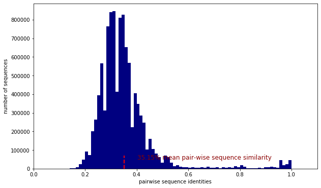

```python
plt.rcParams['figure.figsize'] = 10,6
plt.figure()
binsize = int(round(Dseq['Npos']/2)) #half of the number of positions
plt.hist(pairwiseSeqID_list,bins =binsize, color = 'navy')
avgSID = np.mean(pairwiseSeqID_list)
plt.plot([avgSID,avgSID],[0,70000],'--r',linewidth = 2)
plt.text(avgSID+0.05,50000,str(round(avgSID*100,2))+'% mean pair-wise sequence similarity',fontsize=12,color = 'darkred')
plt.xlabel('pairwise sequence identities')
plt.ylabel('number of sequences')
plt.xlim(0,1.1)
```

Let's look at a 2-D matrix representation of the pair-wise sequence similarities.

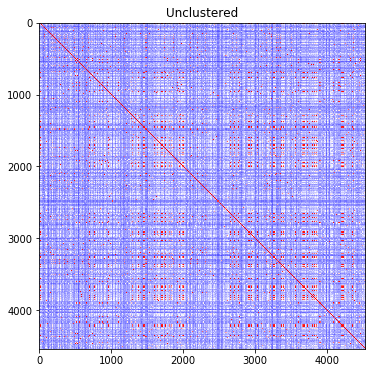

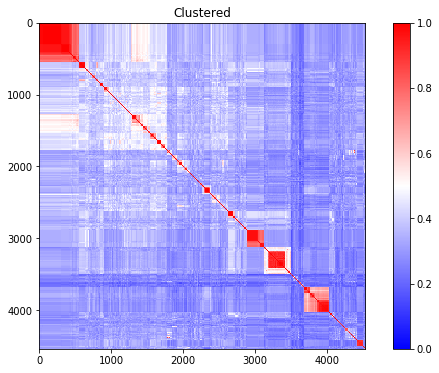

```python
# Cluster the similarity matrix
Z = sch.linkage(Dsca['simMat'],method = 'complete', metric = 'cityblock')
R = sch.dendrogram(Z,no_plot = True)
ind = R['leaves']

plt.figure()
plt.title('Unclustered')
plt.imshow(Dsca['simMat'],interpolation = 'nearest',cmap = 'bwr',vmin = 0,vmax = 1)

# This doesn't tell you anything. You need to cluster this matrix.
plt.figure()
plt.title('Clustered')
plt.imshow(Dsca['simMat'][np.ix_(ind,ind)],vmin = 0,vmax = 1, cmap = 'bwr',interpolation = 'nearest')
plt.colorbar()

#Red means higher similarity, blue means lower similarity.
```

# 3. What does the evolutionary conservation look like across the entire sequence?

### Given prior knowledge about your protein of interest, are the amino acid positions in your protein important to function highly conserved?

```python
position = '27' #Change to desired position in your reference sequence to pull out evolutionary conservation
print ('Conservation at position ' + position + ' is: ' + str(round(Dsca['Di'][Dseq['ats'].index(position)],3)))
```

```
Conservation at position 27 is: 2.358
```

### Visualizing positional convservation ($D_{i}$). Is there sufficient diversity of conservation across positions in the sequence?

```
(0, 4)
```

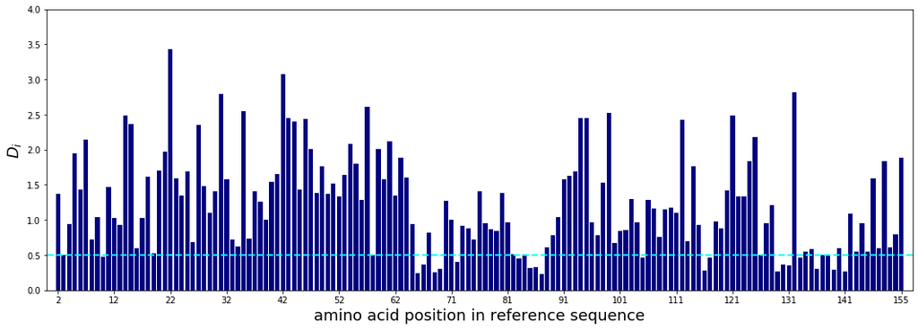

```python
plt.rcParams['figure.figsize'] = 18,6
y = Dsca['Di']
x = Dseq['ats']
plt.bar(x,y,color = 'navy',edgecolor = 'none')

plt.xlabel('amino acid position in reference sequence',fontsize=18)
plt.ylabel('$D_{i}$',fontsize=18)

#X labels for subset of positions. Needed to do this otherwise, the figure is too crowded.
xticklocations = np.arange(0,len(x),10)
xtickPosLabels = [Dseq['ats'][a] for a in xticklocations]
plt.xticks(xticklocations,xtickPosLabels)

#Plots threshold for Di in cyan. Should see some positions where it drops below 0.5 for a sufficient diversity across positions.
plt.plot([-10,len(Dseq['ats'])+10],[0.5,0.5],'--',color = 'cyan',linewidth = 2)

#Set min and max axes of figure
plt.xlim(-2, len(Dseq['ats']))
plt.ylim(0,4)
```

**A cyan line at $D_{i} = 0.5$ marks an empirical conservation threshold.**

# Decomposition of the SCA matrix using scaSectorID

**The scaSectorID script does the preliminaries of sector identification and stores the outputs using the python tool pickle:**

1) Chooses $k_{max}$ (the number of significant eigenmodes) by comparison of the $C_{ij}$ eigenspectrum to that for the randomized matrices

2) Rotates the top $k_{max}$ eigenvectors using independent components analysis

3) Defines the amino acid positions that significantly contribute to each of the independent components (ICs) by empirically fitting each IC to the t-distribution and selecting positions with greater than a specified cutoff (default: p=0.95) on the CDF.

4) Assign positions into groups based on the independent component with which it has the greatest degree of co-evolution.

```python
# run scaSectorID
command = 'scaSectorID -i %s' % (pathPickle)
print (command)
call(command, shell = 'True')

# Load and store results of scaSectorID
db = pickle.load(open(pathPickle,'rb'))
Dsect = db['sector']
```

```
scaSectorID -i /Users/thuynguyen/Documents/pySCA/output/PF00186.db
```

### What are the variables stored in Dsect?

##### Eigendecomposition of the SCA matrix

**Vsca** = $\tilde{V}$ =eigenvectors from eigenvalue decomposition of Csca.

**Lsca** =$\tilde{\Delta}$ = eigenvalues from eignevalue decomposition of Csca.

##### Independent components analysis of eigenvectors

**Vpica** = $\tilde{V}^P_{1...k*}$ = Vsca after Independent Components Analysis (ICA)

**Wpica** = $W$ = transformation matrix to convert from Vsca to Vpica. Uesd in ICA to maximize the independence between eigenvectors.

**ics** = independent components and amino acid positions in each one

##### Determining significant Independent Components

**kpos** = $k*$ = the number of significant eigenmodes from eigenvaule decomposition of Csca. Calculated from sca.choosekpos(Lsca,Lrand). This takes eigenvalues from Csca decomposition and eigenvalues from decomposition of randomized Csca matricies (Crand) and computes the number of significant eigenmodes.

**scaled_pd** = probability t-distributions of co-evolution signal of all positions within each significant IC.

**pd** = parameters of **scaled_pd** (mean and standard deviation)

**cutoff** = significance threshold. Defines significant co-evolving amino acid positions in each IC.

**sortedpos** = from most to least significant signal for each IC.

**icsize** = number of amino acid positions in each significant IC

##### Determining correlations between sequences that contribute to positional correlations found in significant ICs

**Usca** = $\tilde{U}$ = Eigenvectors of sequence correlation matrix. Directly related to the positional correlation matrix by SVD.

**Upica** = $\tilde{U}^P$ = $W\tilde{U}$ = ICA on Usca with transformation matrix, Wpica ($W$)